# CSE5DEV - Assignment 2

Replace Missing vlaues in Species by mode(most frequent observed value)

```r
#identifying indices of missing values in Species column
ind <- which(is.na(dat$Species))
ind
```

```
## [1] 14 92 93
```

```r
#Calculating mode of Species column which is most frequently observed value
Modea <- function(x) {
ux <- unique(x)
tab <- tabulate(match(x, ux))
ux[tab == max(tab)]
}
mod<- Modea(dat$Species[-ind])
dat$Species[ind] <- mod

any(is.na(dat$Species))
```

```
## [1] FALSE
```

```r
sum(dat$Species == "")
```

```
## [1] 0
```

```r
sum(dat$Species %in% c("NA", "N/A"))
```

```
## [1] 0
```

Statistical Comparision on Species for both datasets Summary statistics for each species of recovered dataset

```r
# Frequency for Species column of recovered dataset
print(table(dat$Species))
```

```
##
##     setosa versicolor  virginica
##         49         48         53
```

```r
# Frequency for Species column of original dataset
print(table(original$Species))
```

```
##
##     setosa versicolor  virginica
##         50         50         50
```

```r
#summary statistics for each species of recovered dataset
summary_stats <- dat %>%
  group_by(Species) %>%
  summarise(
    Min_Petal_Width = min(Petal.Width, na.rm = TRUE),
    Max_Petal_Width = max(Petal.Width, na.rm = TRUE),
    Mean_Petal_Width = mean(Petal.Width, na.rm = TRUE),
    Median_Petal_Width = median(Petal.Width, na.rm = TRUE),

    Min_Petal_Length = min(Petal.Length, na.rm = TRUE),
    Max_Petal_Length = max(Petal.Length, na.rm = TRUE),
    Mean_Petal_Length = mean(Petal.Length, na.rm = TRUE),
    Median_Petal_Length = median(Petal.Length, na.rm = TRUE),

    Min_Sepal_Width = min(Sepal.Width, na.rm = TRUE),
    Max_Sepal_Width = max(Sepal.Width, na.rm = TRUE),
    Mean_Sepal_Width = mean(Sepal.Width, na.rm = TRUE),
    Median_Sepal_Width = median(Sepal.Width, na.rm = TRUE),

    Min_Sepal_Length = min(Sepal.Length, na.rm = TRUE),
    Max_Sepal_Length = max(Sepal.Length, na.rm = TRUE),
    Mean_Sepal_Length = mean(Sepal.Length, na.rm = TRUE),
    Median_Sepal_Length = median(Sepal.Length, na.rm = TRUE)
  )

# Print the summary statistics
print(summary_stats)
```

```
## # A tibble: 3 × 17
##   Species    Min_Petal_Width Max_Petal_Width Mean_Petal_Width Median_Petal_Width
##   <chr>                <dbl>           <dbl>            <dbl>              <dbl>
## 1 setosa                 0.1             0.6            0.249                0.2
## 2 versicolor             1               1.8            1.33                 1.3
## 3 virginica              0.1             2.5            1.96                 2
## # ℹ 12 more variables: Min_Petal_Length <dbl>, Max_Petal_Length <dbl>,
## #   Mean_Petal_Length <dbl>, Median_Petal_Length <dbl>, Min_Sepal_Width <dbl>,
## #   Max_Sepal_Width <dbl>, Mean_Sepal_Width <dbl>, Median_Sepal_Width <dbl>,
## #   Min_Sepal_Length <dbl>, Max_Sepal_Length <dbl>, Mean_Sepal_Length <dbl>,
## #   Median_Sepal_Length <dbl>
```

Summary statistics for each species of original dataset

```r
#summary statistics for each species of original dataset
summary_stats2 <- original %>%
  group_by(Species) %>%
  summarise(
    Min_Petal_Width = min(Petal.Width, na.rm = TRUE),
    Max_Petal_Width = max(Petal.Width, na.rm = TRUE),
    Mean_Petal_Width = mean(Petal.Width, na.rm = TRUE),
    Median_Petal_Width = median(Petal.Width, na.rm = TRUE),

    Min_Petal_Length = min(Petal.Length, na.rm = TRUE),
    Max_Petal_Length = max(Petal.Length, na.rm = TRUE),
    Mean_Petal_Length = mean(Petal.Length, na.rm = TRUE),
    Median_Petal_Length = median(Petal.Length, na.rm = TRUE),

    Min_Sepal_Width = min(Sepal.Width, na.rm = TRUE),
    Max_Sepal_Width = max(Sepal.Width, na.rm = TRUE),
    Mean_Sepal_Width = mean(Sepal.Width, na.rm = TRUE),
    Median_Sepal_Width = median(Sepal.Width, na.rm = TRUE),

    Min_Sepal_Length = min(Sepal.Length, na.rm = TRUE),
    Max_Sepal_Length = max(Sepal.Length, na.rm = TRUE),
    Mean_Sepal_Length = mean(Sepal.Length, na.rm = TRUE),
    Median_Sepal_Length = median(Sepal.Length, na.rm = TRUE)
  )

# Print the summary statistics
print(summary_stats2)
```

```
## # A tibble: 3 × 17
##   Species    Min_Petal_Width Max_Petal_Width Mean_Petal_Width Median_Petal_Width
##   <chr>                <dbl>           <dbl>            <dbl>              <dbl>
## 1 setosa                 0.1             0.6            0.246                0.2
## 2 versicolor             1               1.8            1.33                 1.3
## 3 virginica              1.4             2.5            2.03                 2
## # ℹ 12 more variables: Min_Petal_Length <dbl>, Max_Petal_Length <dbl>,
## #   Mean_Petal_Length <dbl>, Median_Petal_Length <dbl>, Min_Sepal_Width <dbl>,
## #   Max_Sepal_Width <dbl>, Mean_Sepal_Width <dbl>, Median_Sepal_Width <dbl>,
## #   Min_Sepal_Length <dbl>, Max_Sepal_Length <dbl>, Mean_Sepal_Length <dbl>,
## #   Median_Sepal_Length <dbl>
```

#Box plot for Petal.Length comparing both datasets

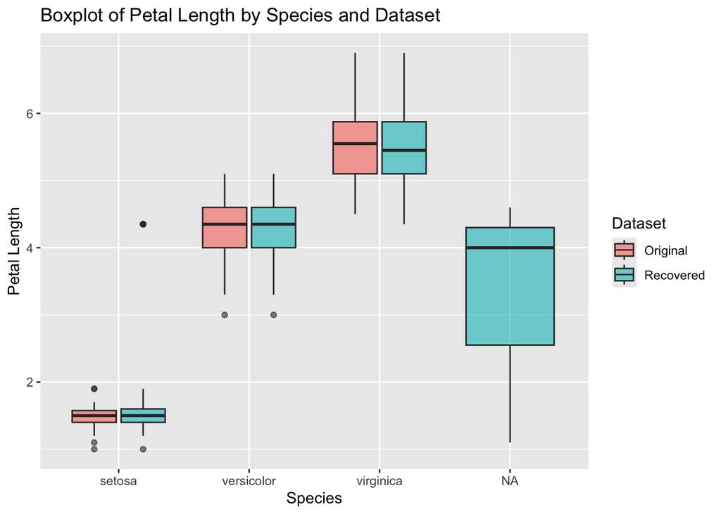

```r
ggplot(combined_data, aes(x = Species, y = Petal.Length, fill = Dataset)) +
  geom_boxplot(alpha = 0.6) + #for plotting boxplot
  labs(title = "Boxplot of Petal Length by Species and Dataset",
       x = "Species",
       y = "Petal Length")
```

#Box plot for Petal.Width comparing both datasets

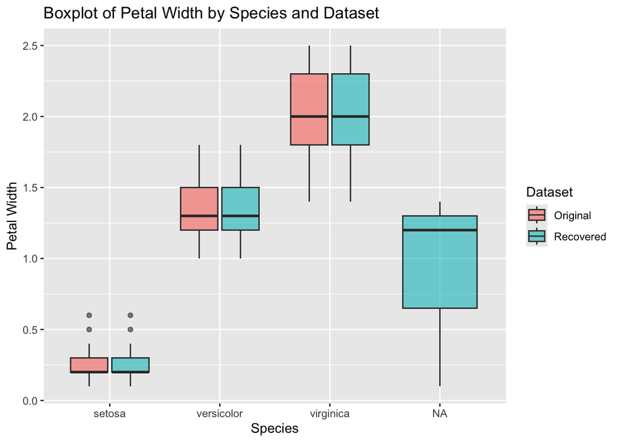

```r
ggplot(combined_data, aes(x = Species, y = Petal.Width, fill = Dataset)) +
  geom_boxplot(alpha = 0.6) +
  labs(title = "Boxplot of Petal Width by Species and Dataset",
       x = "Species",
       y = "Petal Width")
```

#Box plot for Sepal.Length comparing both datasets

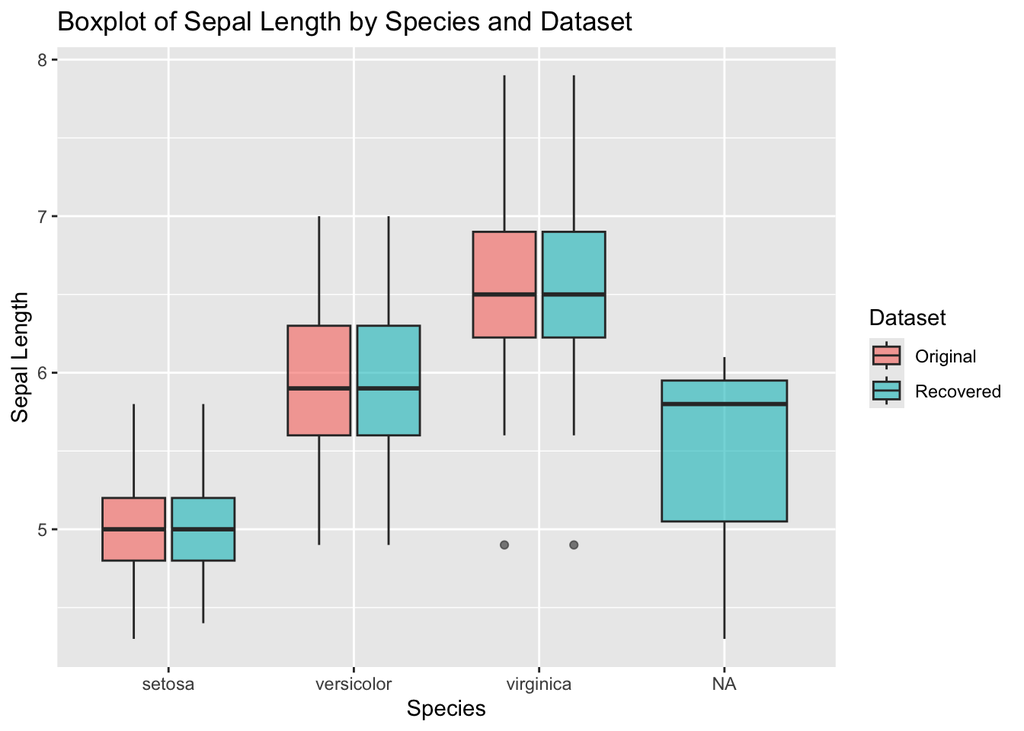

```r
ggplot(combined_data, aes(x = Species, y = Sepal.Length, fill = Dataset)) +
  geom_boxplot(alpha = 0.6) +
  labs(title = "Boxplot of Sepal Length by Species and Dataset",
       x = "Species",
       y = "Sepal Length")
```

#Box plot for Sepal.Width comparing both datasets